# Chapter 5: Clustering

```r
library(here)
library(vegan)
library(scRNAseq) #bioconductor
  # In windows conda R "BiocManager::install("scRNAseq", INSTALL_opts=c("--no-multiarch"))"
library(clusterExperiment) #bioconductor
  # requires gsl, so on linux terminal "sudo apt-get install libgsl-dev" to allow installation of gsl on R (install.packages("gsl")) or BiocManager::install("clusterExperiment") might install it w/ other packages
#browseVignettes("clusterExperiment")
library(limma)
library("flowCore") ; library("flowViz")
library(Biobase)  #bioconductor
  # In windows conda R "BiocManager::install("Biobase", INSTALL_opts=c("--no-multiarch"))"
library(readr)
library(flowPeaks) #bioconductor
library(ggcyto) #bioconductor
library(labeling)
library(dbscan)
library(pheatmap)
library(dplyr)
library(fpc) ; library(cluster)
library(Hiiragi2013)
library(clue)
library(ggbeeswarm)
library(mixtools)
library(vcd)
library(dada2) #bioconductor
library(kernlab)
```

**Table of contents**

[1] Clustering  
[2] Chapter Summary  
[3] What are the data and why do we cluster them?  
[4] How do we measure similarity?  
[5] Nonparametric mixture detection  
[6] Clustering examples: flow cytometry and mass cytometry  
[7] Hierarchical clustering  
[8] Validating and choosing the number of clusters  
[9] Clustering as a means for denoising  
[10] Excercises  
[X] Misc.

**Clustering**<sup>Return</sup>

- Making categories within a set of scientific data
  - Can model data as mixtures from different groups/populations w/ parametric model (CH4) -> EM algorithm to assign components (distributions)
  - Making groups via clustering -> no elliptical shapes
    - **elliptical shapes generated by mixture models w/ multivaraibles in normal distribution -> implies elliptic cluster** boundries
  - Clustering is for continous/quasi-continous data
    - Makes categorical group variable -> helps simplify decisions made
    - ex) Medical decisions simplified by replacing high-dimension diagnostic measurements via simple groupings *numbers w/ glucose lvls, hemoglobin lvls, etc -> grouped via assigning as diabetes mellitus
  - This CH -> find meaningful clusters/groups in low or high dimension non-parametric data
    - problem: Clustering algorithms designed to find clusters, so forced to cluster even if no grouping actually exists
      - Need to validate clusters manually (esp. if no prior knowledge to support clusters)

**Chapter Summary**<sup>Return</sup>

- **How to compare observations?**
  - First step is to find the right distance for clustering analysis
  - Garbage in = Garbage out
    - Choose distance that is scientifically meaningful & compare output of other possible distance combinations
    - Same data may require different distances if different scientific objectives
- **Two ways of clustering**
  1. Iterative partitioning approach -> Kmeans & Kmedoids (PAM): Alternate between estimating cluster centers & assiging points to clusters
  2. Hierarchical clustering approach -> Collect points & growing clusters, then nest sequences into sets represented by hierarchical clustering trees
- **Biological examples**
  - Clustering useful for finding latent classes in single cell measurements (Immunology & single cell data)
  - Density-based clustering useful for low-dimension data w/ no sparsity issue
- **Validating clusters**
  - Cluster algorithms always asign clusters, so need to assess #of clusters & choose if representitive of data
  - Use visualization tools & repeating clustering w/ resamples of data (self note- bootstrap?)
    - Statistical tests (WSS/BSS) or (log(WSS)) calibrated w/ simulations of data
      - Used to understand group structure
      - Provide benchmark for choosing #of clusters on new data
    - Use of biological prior knowledge is best approach for validating clusters
- **Distances & probabilities**
  - Instead of distances, can account for *baseline frequencies & local densities for clustering*
    - Essential clustering to denoise 16S rRNA seq reads (true class/taxa group occur at different freqs)

**What are the data and why do we cluster them?**<sup>Return</sup>

- Clustering may lead to discoveries
  - ex) map cases of outbreaks - may find clusters of cases
    - collect info about situation within clusters, proximity of cases within clusters -> may reveal something latent, such as source
  - WWII bombing locations data show that targets were random
  - Clustering useful for complex multivariable data
    - Clustering is unsupervised = all variables have same status based on info from explanatory variables (not predicting/learning value of one variable)
    - Exploratory techniques -> grouping is important to interpret data
      - ex) Understanding cancer biology -> tumors clustered based upon anatomical location & histopathology via molecular data (expression) -> clusters may refine disease types
        - Relevance of clusters via evidence (associated w/ different outcomes)
  - CH4 mainly based upon EM algorithm for clustering latent groups
    - CH5 clustering techniques are more general and can be used for complex data
      - Most are based on distances beteween pairs of obs (distances vs all, or some) *Does not make assumptions about generative mechanisms of data distributions (normal, gamma-Poisson, etc.)
        - Many clustering algorithms used in softwares (based on diversity of data types & objectives of study)

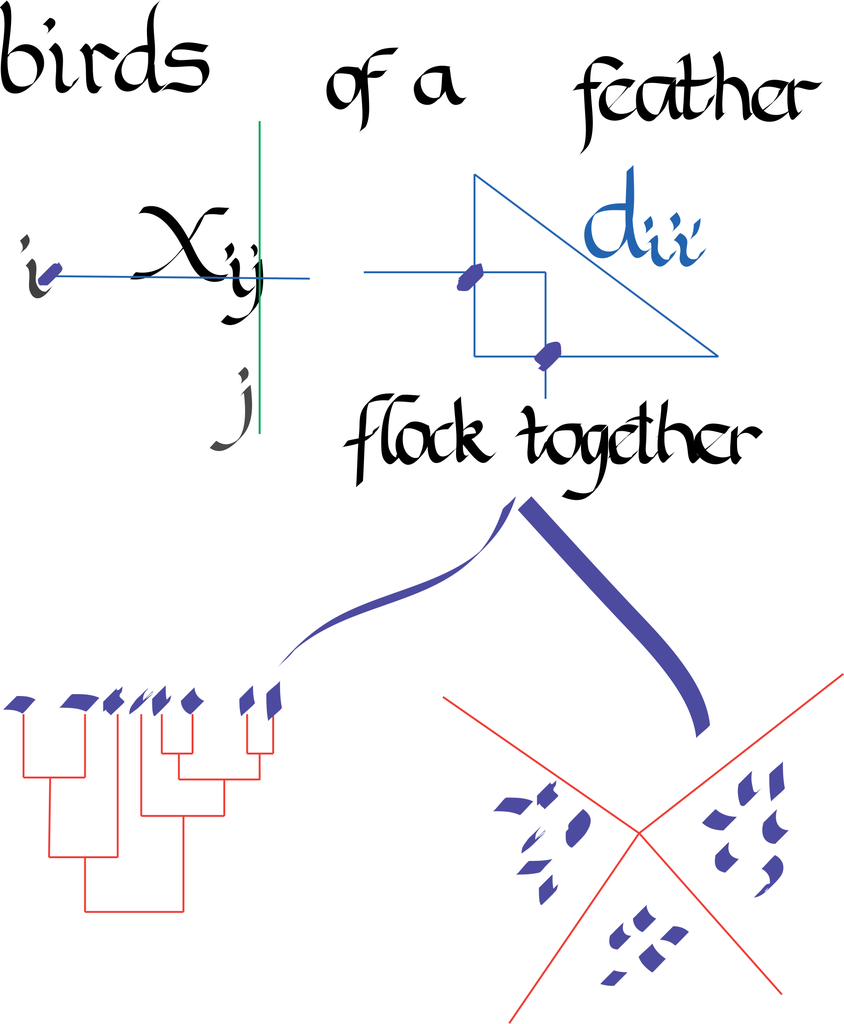

> We decompose the choices made in a clustering algorithm according to the steps taken:  
> starting from an observations-by-features rectangular table X -> choose an observations-to-observations distance measure and compute the distance matrix, here schematized by the triangle.  
> The distances are used to construct the clusters.  
> On the left, we schematize agglomerative methods, that build a hierarchical clustering tree;  
> on the right, partitioning methods that separate the data into subsets.  
> Both types of methods require a choice to be made: the number k of clusters.  
> For partitionning approaches such as k-means this choice has to be made at the outset;  
> for hierarchical clustering this can be deferred to the end of the analysis.

**How do we measure similarity?**<sup>Return</sup>

- First, decide what similar means
  - ex) ways to compare birds - distance of size vs weight = one way to cluster
    - or distance of diet vs habitat = different way to cluster
  - **Choose relevant features & combine differences between multiple features into a single number**
    - How distances measured & similarities between obs defined have heavy impact on clustering result

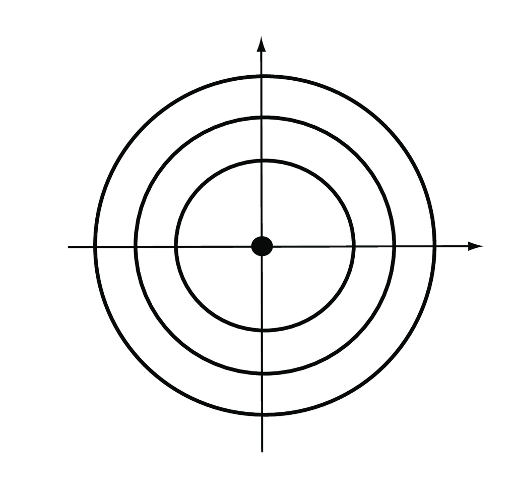

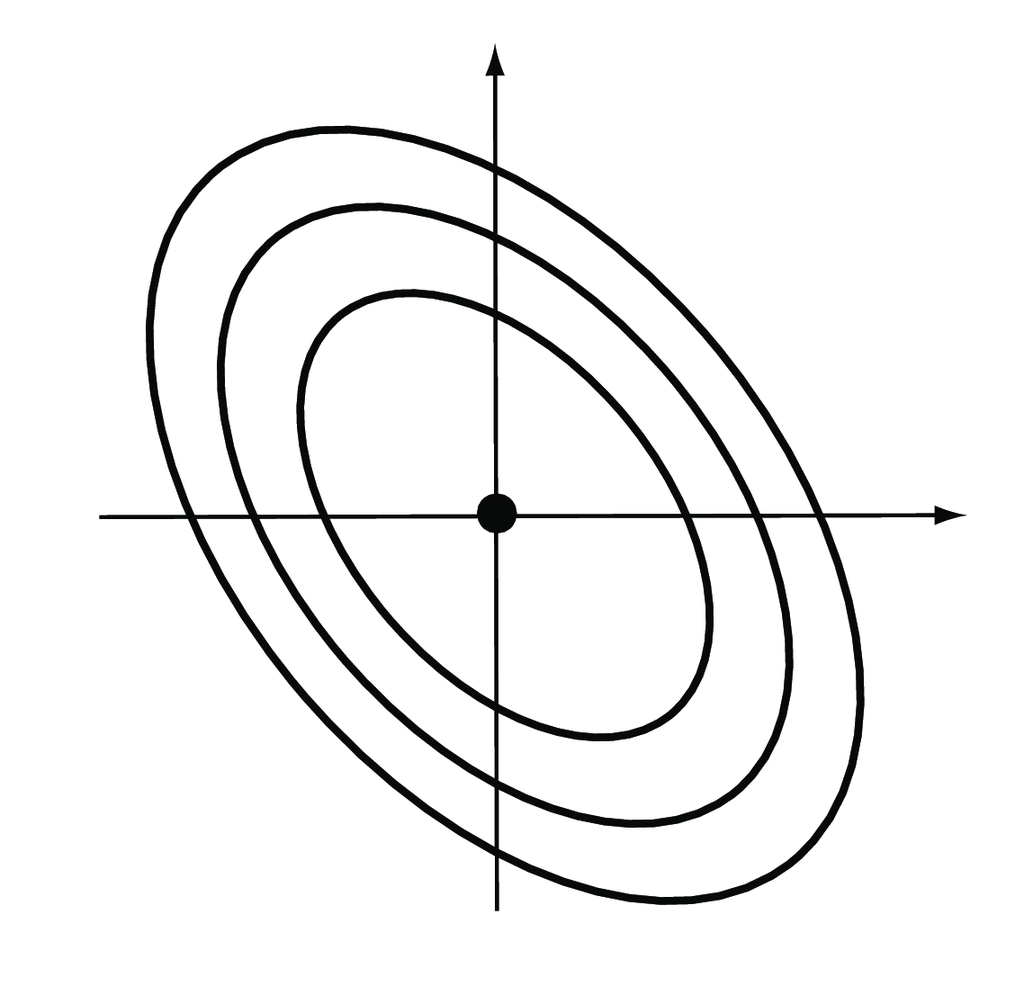

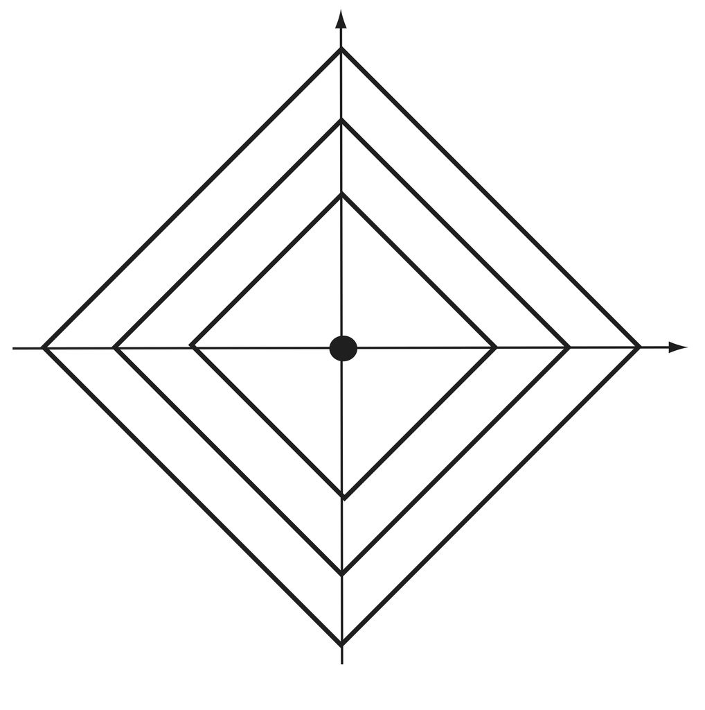

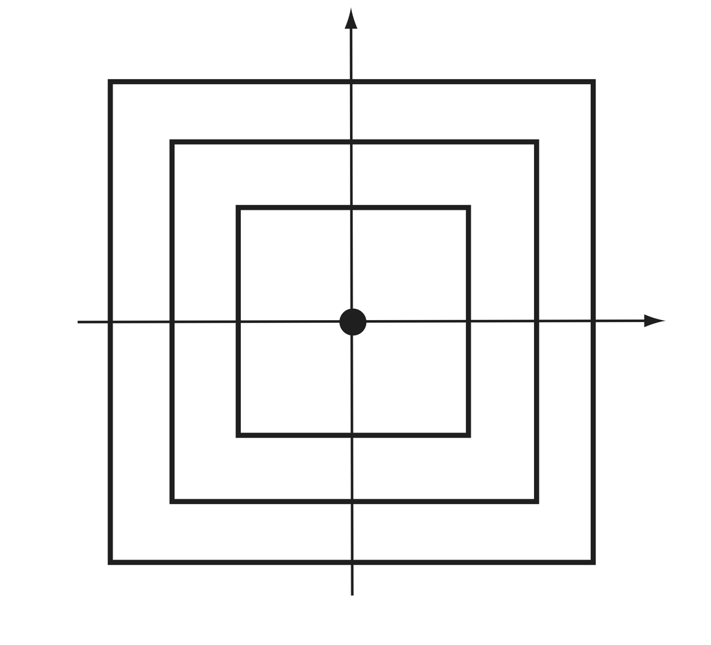

> Equal-distance contour plots according to four different distances: points on any one curve are all the same distance from the center point.
- Similarity selection Choices
  - **Euclidean** = distance between 2 points (A=(a1,…,an)) & (B=(b1,…,bn)) in p-dimensional space (where p=features) -> square root of sum of squares of differences in all p-coordinate directions

    $$\begin{equation*}
    d(A,B)=\sqrt{(a_1-b_1)^2+(a_2-b_2)^2+... +(a_p-b_p)^2}.
    \end{equation*}$$
  - **Weighted Euclidean** = distance by generalizing ordinary Euclidean distance. -> Assign different weights to different directions in feature space
    - Seen in ch2. -> Chi-squared distance
      - Used to compare rows in contingency tables & weight of each feature = inverse of expected value
    - Mahalanobis distance -> another weighted Euclidean distance
      - Accounts for different features having different dynamice range
        - Some features -ve/+ve correlation w/ eachother
      - Weights derived via covarience matrix of features (seen in first question below)
  - **Manhattan/City Block/Taxicab/L1** = distance by sum of absolute differences in all coordinates

    $$\begin{equation*}
    d(A,B)=|a_1-b_1|+|a_2-b_2|+... +|a_p-b_p|.
    \end{equation*}$$
  - **Maximum/L∞** = distance by max absolute differences between coordinates

    $$\begin{equation*}
    d_\infty(A,B)= \max_{i}|a_i-b_i|.
    \end{equation*}$$
  - **Minkowski** = Euclidean distance without the square -> exponent 2 is replaced with m

    $$\begin{equation}
    d(A,B) = \left( (a_1-b_1)^m+(a_2-b_2)^m+... +(a_p-b_p)^m \right)^\frac{1}{m}.
    \tag{5.1}
    \end{equation}$$
  - **Edit/Hamming** = Simplest distance to compare character sequences
    - Counts #differences between 2 character strings
      - ex) nucleotide or AA seqs -> different character substitutions associated w/ different contributions to distance (accounts ofr physical/evolutionary similarity)
      - Allows for InDels
  - **Binary** = Distance by two binary vectors, where binary values are coordinates
    - ex) Non-zero elements = on-coordinates & zero elecments = off-coordinates
    - Proportion of features w/ only one binary bit “on-coordinate” among features w/ at least one binary bit “on-coordinate”
  - **Jaccard Distance** = Trait occurenence or features in ecological mutation data -> translated into presence/absence (1’s or 0’s)
    - Co-occurence more informative than co-abscence
      - ex) compare mutation patterns in HIV
        - Co-existence of mutation in 2 different strains is more important observation vs co-absence of mutation
        - Use **Jaccard Index**
          - Two observation vectors (S & T)
          - f<sub>11</sub> = #times features co-occur in both vectors
          - f<sub>10</sub> = #times features occurs in vector S but not in T (and vice versa f<sub>01</sub>)
          - f<sub>00</sub> #times features co-absent in both vectors

            $$\begin{equation}
            J(S,T) = \frac{f_{11}}{f_{01}+f_{10}+f_{11}},
            \tag{5.2}
            \end{equation}$$
            Note that the Jaccard Index ignores co-absence (f<sub>00</sub>)

            $$\begin{equation}
            d_J(S,T) = 1-J(S,T) = \frac{f_{01}+f_{10}}{f_{01}+f_{10}+f_{11}}.
            \tag{5.3}
            \end{equation}$$
  - **Correlation based distance** = distance based upon the correlation of A&B

    $$\begin{equation*}
    d(A,B)=\sqrt{2(1-\text{cor}(A,B))}.
    \end{equation*}$$
- 17. Which of the two cluster centers is the red point closest to?

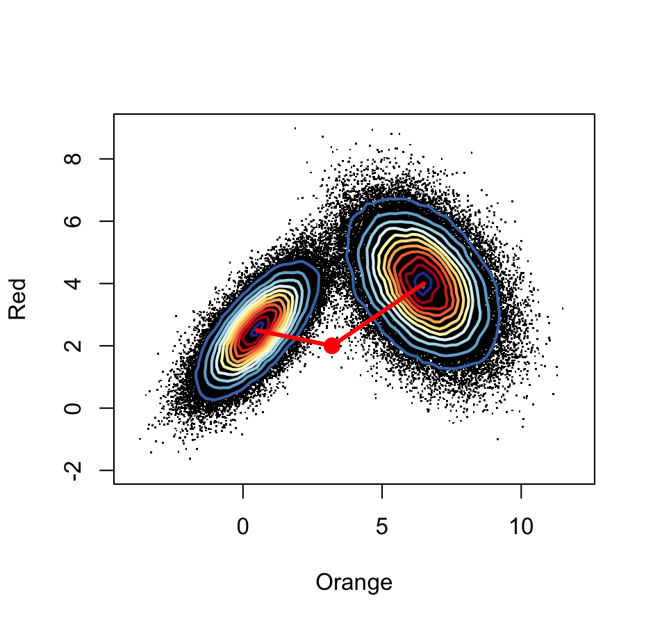

- 1. Can use Euclidean distance metric to decide that red point is closest to left cluster
  - Problem = features have different ranges & correlations which differ between both clusters
  - Solution = cluster using specific Mahalanobis distances (Weighted Euclidean)
    - Figure shows contour lines for both clusters -> obtained via density estimate
    - Mahalanobis distance approximates contours w/ ellipses
      - Distance between red point & each cluster centers = #contour lines crossed
      - Can see right group is more spread (red point is actually closer to the right)
- Distances computation using R
  - `dist()` designed to use less space vs full n<sup>2</sup> positions (complete n x n distance matrix between n objects)
    - Function computes 1/6 choices of distances (euclidean, maximum, manhattan, canberra, binary, minkowski) -> output vector of values for reconstructing complete distance matrix
    - Function returns object of class “dist” = has relevant vector size n x (n-1)/2

```r
mx <- c(0,0,0,1,1,1)
my <- c(1,0,1,1,0,1)
mz <- c(1,1,1,0,1,1)
mat <- rbind(mx, my, mz)
dist(mat)
```

```
         mx       my
my 1.732051
mz 2.000000 1.732051
```

```r
dist(mat, method="binary")
```

```
          mx        my
my 0.6000000
mz 0.6666667 0.5000000
```

- To **access particular distance** (ex) distance between obs 1 &2) -> need to **turn class “dist” to “matrix”**

```r
load(here("BookStuff", "data", "Morder.RData"))
sqrt(sum((Morder[1,]-Morder[2,])^2)) #Euclidean formula
```

```
[1] 5.593667
```

```r
as.matrix(dist(Morder))[2, 1]
```

```
[1] 5.593667
```

- Going back to the Jaccard distance example as explained above (distance between 2 HIV strains w/ co-mutations)

```r
mut <- read.csv(here("BookStuff", "data", "HIVmutations.csv"))
mut[1:3, 10:16]
```

|  | p32I | p33F | p34Q | p35G | p43T | p46I | p46L |
| --- | --- | --- | --- | --- | --- | --- | --- |
| 1 | 0 | 1 | 0 | 0 | 0 | 0 | 0 |
| 2 | 0 | 1 | 0 | 0 | 0 | 1 | 0 |
| 3 | 0 | 1 | 0 | 0 | 0 | 0 | 0 |

- 17. Compare Jaccard distance between mutations in HIV data “mut” to correlation based distance (use function `vegdist()` in R-package vegan)

```r
mutJ <- vegdist(mut, "jaccard")
mutC <- sqrt(2*(1-cor(t(mut)))) #Correlation based distance formula
mutJ
```

```
          1         2         3         4
2 0.8000000
3 0.7500000 0.8888889
4 0.9000000 0.7777778 0.8461538
5 1.0000000 0.8000000 0.8888889 0.9000000
```

```r
as.dist(mutC)
```

```
         1        2        3        4
2 1.186342
3 1.104026 1.302931
4 1.318368 1.133893 1.298780
5 1.452966 1.186342 1.302931 1.318368
```

- Interesting to compare complex objects not in vectors or real numbers via dissimilarities or distances
  - Grower’s distance for data of mixed modalities (categorical factors+continuous variables) -> computed using `daisy()`
  - Distances can be defined between pairs of objects (not just points in R or character seqs)
    - ex) `shortest.paths()` from igraph package (ch10) computes distance between vertices on graph
    - `cophenetic()` computes distances betweens leaves of a tree (seen on below image)
    - `dist.multiPhylo()` from distory package can compute distance between trees

[figure not shown]

- Jaccard index between graphs can be computed via looking at two graphs built on same nodes -> count #co-occuring edges
  - use `similarity()` from igraph package
  - Distances & dissimilarities used to compare images, sounds, maps, & documents
    - Distance encompasses domain knowledge (if chosen carefully) -> can lead to solution for hard problems w/ heterogenous data
    - Ask waht is relevant closeness/similairty for data -> find usefuly way to represent similarity (Ch9)

[figure not shown]

> Figure 5.7: The lower triangle of distances can be computed by any of a hundred different functions in various R packages (`vegdist()` in vegan, `daisy()` in cluster, `genetic_distance()` in gstudio, `dist.dna()` in ape, `Dist()` in amap, `distance()` in ecodist, `dist.multiPhylo()` in distory, `shortestPath()` in gdistance, `%dudi.dist()` and `dist.genet()` in ade4).

**Nonparametric mixture detection**<sup>Return</sup>

- k-methods: k-means, k-medoids, and PAM (centers of groups = medoids = PAM = partitioning around medoids)
  - Partitioning/iterative relocation methods on high-dimensional data which can’t easily apply probability densities (due to dimensionality curse)
    - Can’t apply probability densities w/ EM algorithm & parametric mixture modeling
  - After the distance measure, we have to decide on the number of clusters k
    - PAM (Partitioning around medoids) works as follows:
      1. Matrix of *p* features measured on set of *n* observations
      2. Randomly pick *k* distinct cluster centers from the *n* observations = “seeds”
      3. Assign remaining observations to group based on closest center
      4. In each group, choose a new center from the observations within the group -> sum of distances of group members to new center must be minimized = **medoid**
      5. Repeat steps 3-4 until groups stabilize
  - Each time the PAM algorithm is ran, different inital seeds will be picked in step 2 (same as EM algorithm)
    - This can led to difference in final results
    - `pam()` function in the cluster package
  - Slight variation of the PAM method replaces the medoids to arithmetic means of clusters (centers of gravity) = **k-means**
    - In PAM algorithm, the centers are observations (usually not the case w/ k-means algorithm b/c arithmetic mean medoid)
    - `kmeans()` from the stats package

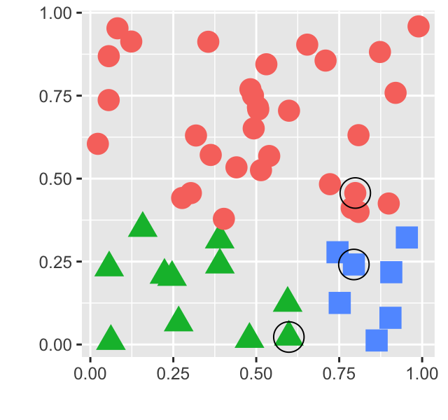

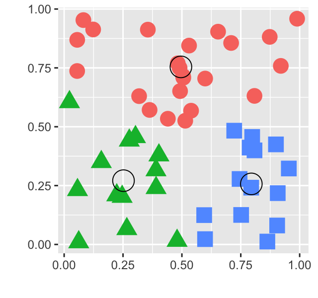

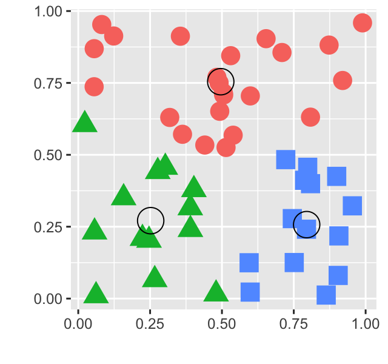

> An example run of the k-means algorithm.  
> The initial, randomly chosen centers (black circles) and groups (colors) are shown in the top panel. The group memberships are assigned based on their distance to centers. At each iteration, the group centers are redefined, and the points reassigned to the cluster centers.
- k-methods are most common methods used for clustering
  - works well when clusters are comparable in size & convex(blob-shape)
    - If clusters are different in size, larger clusters will be broken up (same w/ groups in non-spherical or non-elliptic shapes)
- 17. k-means algorithm alternates by computing average pt & assigning points to clusters. How does this alteration, iteration method differ from EM-algorithm
- 1. Each point in EM algorithm is used for computing mean of all groups via probabilitically assigned weight
  - Each point in k-means algorithm is assigned to a cluster or not, so points participate only in computation of center of a single cluster

#### Tight clusters w/ resampling

```r
data("fluidigm", package="scRNAseq") #needs scRNAseq package
se <- fluidigm[, fluidigm$Coverage_Type == "High"] #subset the df fluidigm to have all rows but only column "Coverage_Type" where values = "High"
assays(se) <- list(normalized_counts=round(limma::normalizeQuantiles(assay(se)))) #normalizeQuantiles requires the limma package
ce <- clusterMany(se, clusterFunction="pam", ks=5:10, run=TRUE, isCount=TRUE, reduceMethod="var", nFilterDims=c(60,100,150))
```

```
Note: Not all of the methods requested in 'reduceMethod' have been calculated. Will calculate all the methods requested (any pre-existing values -- filtering statistics or dimensionality reductions -- with these names will be recalculated and overwritten): var.
```

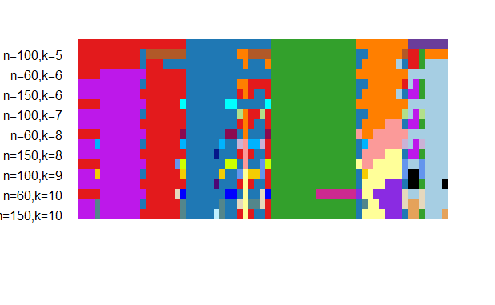

```r
clusterLabels(ce) <- sub("FilterDims", "", clusterLabels(ce)) #replace the "FilterDims" values from the cluster labels of ce w/ blank
plotClusters(ce, whichClusters="workflow", axisLine=-1)
```

> Comparison of clustering results (rows), for different numbers of included genes and for varying numbers of clusters, k. Each column of the heatmap corresponds to a celXl, and the colors represent the cluster assignments.

**Clustering examples: flow cytometry and mass cytometry**<sup>Return</sup>

- Studying measurements on signle cells improves focus & resolution -> allows analysis of cell types & dynamics
  - Flow cytometry allows simultaneous measurements of ~10 different cell markers
  - Mass cytometry expands collection of measurements to max 80 proteins per cell
  - These techniques allow studying immune cell dynamics
- Flow & mass cytometry
  - During immune cell devlopment -> unique combos of proteins @surfaces expressed = markers called CD (clusters of differentiation)
    - These are collected by flow cytometry (via fluorescence) or mass cytometry (single cell mass spec)
    - ex) CD4 of Th cells (CD4+)
      - Use bioconductor package for cytometry data (flowCore & flowWiz) to read fcsB dataset

```r
fcsB <- read.FCS(here("BookStuff", "data", "Bendall_2011.fcs"))
slotNames(fcsB)
```

```
[1] "exprs"       "parameters"  "description"
```

[figure not shown]

> Scatterplot of two of the variables available in the fcsB data. We can see clear bimodality and clustering in these two dimensions.
- Qa) Look at structure of fcsB (`colnames()`) - how many variables measured?
- Aa)

```r
length(colnames(fcsB))
```

```
[1] 41
```

- Qb) Subset the data to look at first few rows (`Biobase::exprs(fcsB)`) - how many cells were measured?
- Ab)

```r
Biobase::exprs(fcsB[1:3,])
```

```
     Time Cell_length Ir(190.960)-Dual Ir(192.962)-Dual Rh(102.905)-Dual
[1,]   15    31.74782       1189.36206        784.00000        84.923141
[2,]   29    32.73994        725.42944        784.00000        12.571655
[3,]   30    29.76359         14.76599         49.96379         3.707486
     In(114.903)-Dual Cd(109.903)-Dual Cd(110.904)-Dual Cd(111.902)-Dual
[1,]         5.672130       15.7740660        -1.376150         6.436958
[2,]        12.750891       -0.1887358        -2.648802        -1.471898
[3,]         8.286617        0.4298253        -2.444678         6.791304
     Cd(113.903)-Dual La(138.906)-Dual Pr(140.907)-Dual Nd(141.907)-Dual
[1,]        6.2128391         14.68693        1970.0000         2.209156
[2,]       -0.7862989         89.21723         558.0174         3.443998
[3,]       15.0061932         14.08984        1364.9680         7.559930
     Nd(143.910)-Dual Nd(144.912)-Dual Nd(145.913)-Dual Nd(147.916)-Dual
[1,]         2.364415       -1.2065018       -0.3819572       -0.3784404
[2,]        22.432457       -0.6339307        1.2526673       -1.7176632
```

[output cut: 29 more lines]